# ¿Dónde es mejor sembrar maíz según la temperatura en indiana?

## Kriging universal

Si bien el kriging ordinario dio muy buenos resultados, hay que notar la tendencia lineal existente entre la coordenada en y de los datos y la respuesta considerada como se puede ver a continuación.

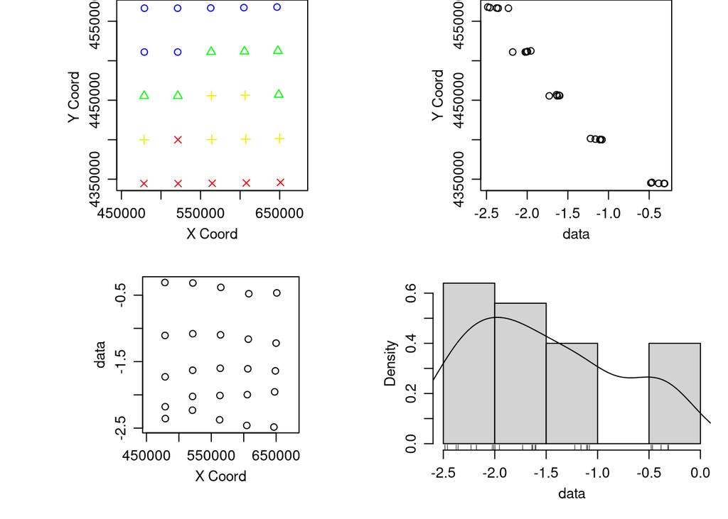

Por tanto se opta por ajustar un modelo de kriging universal con media lineal en aras de observar si dicha consideración mejora el rendimiento del modelo. Este fue el resultado.

Se puede notar que en cuanto a la predicción es distinto al modelo seleccionado previamente, sin embargo el patrón en el mapa de calor de las predicciones se ajusta más a lo que se esperaría en la realidad.

### Predicción

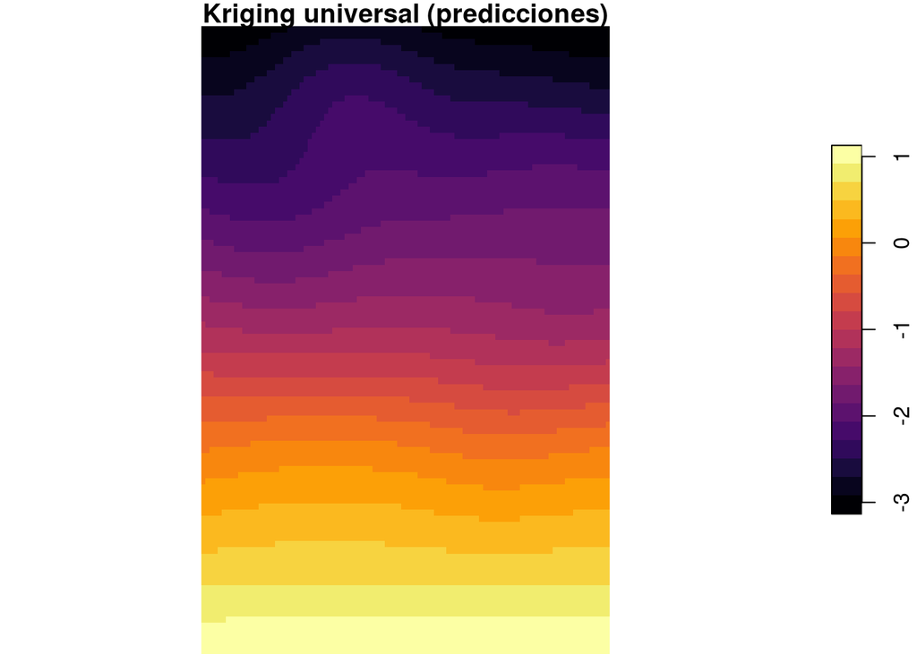

### Desviación

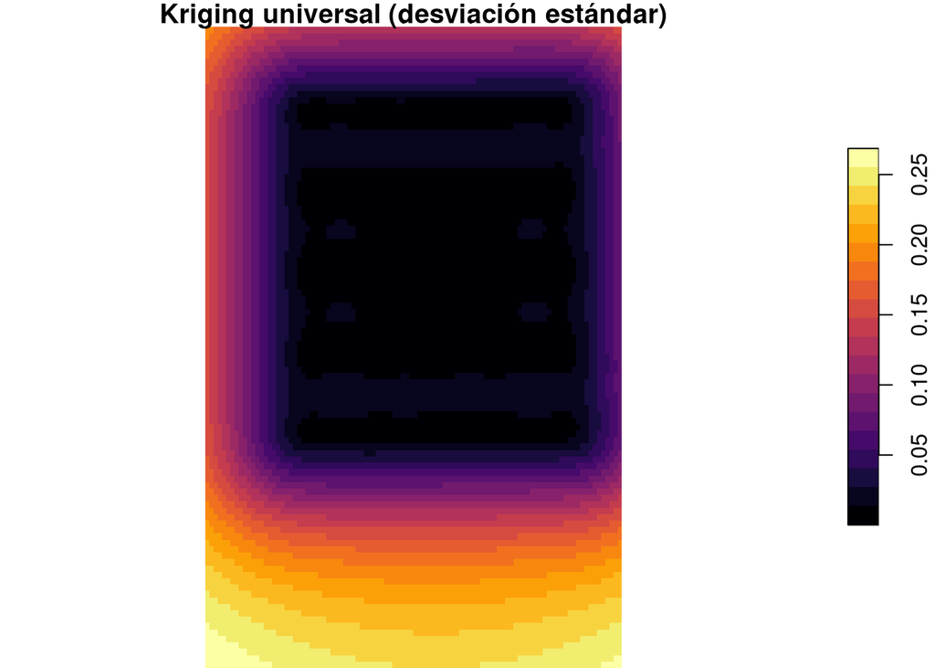

Una vez obtenido el resultado del modelo, este se compara con el modelo ajustado vía kriging ordinario.

Comparación de modelos

| Modelo | RMSE |
| --- | --- |
| Temperatura promedio kriging ordinario | 0.0454395 |
| Temperatura promedio kriging universal | 0.0341727 |

Si bien presenta una disminución del RMSE que a priori parece no muy grande, es fundamental tener en cuenta que esta métrica es de decrecimiento lento cuando se acerca al cero por lo que dicho decremento realmente es una gran mejora en el modelo. Adicionalmente, el ajuste a través de kriging universal presenta una menor variabilidad en las estimaciones respecto a su similar, por lo que en definitiva es el seleccionado entre todos los candidatos considerados previamente.

# Resultados ubicados geográficamente

## Ubicación de los puntos en el mapa

Incialmente se tiene una visualización de las unidades de muestreo en el mapa, se cuenta con 25 puntos donde se tomaron mediciones tanto de la irradiación solar como de la temperatura como ya se había descrito anteriormente.

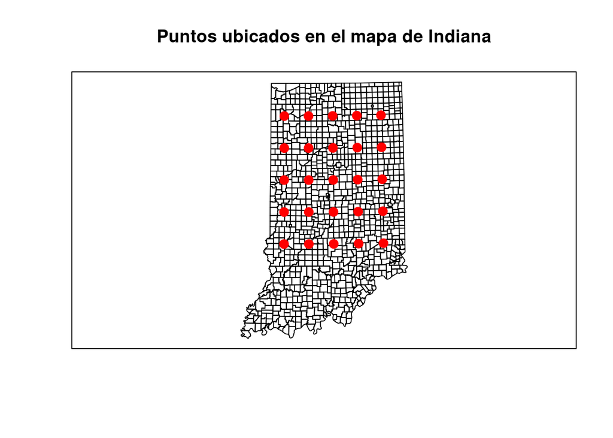

Es importante saber donde se encuentran estas unidades ya que el kriging es un método de interpolación exacto, por lo que el valor de las variables de interés tendrá el mismo valor de predicción que observado y esto es un aspecto a tener en cuenta a la hora de hacer conclusiones.

## Puntos de predicción

Adicional a lo enunciado anteriormente, se presenta para información del lector, aquellas ubicaciones geográficas sobre las cuales se realizaron las predicciones usando el modelo seleccionado.

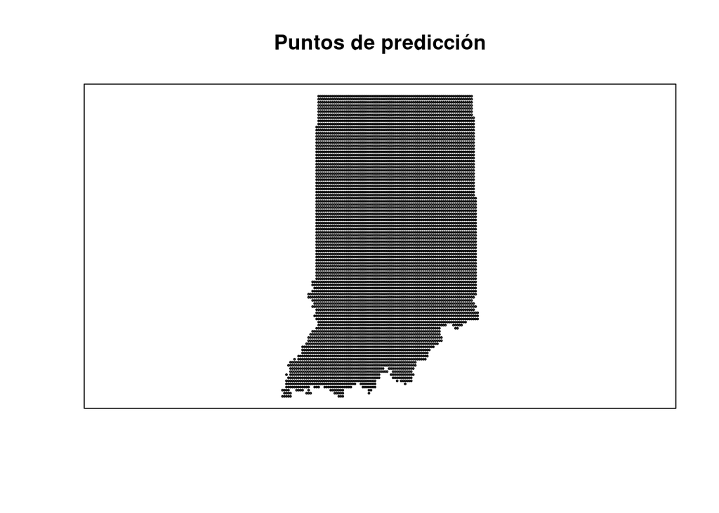

## Presentación del mejor modelo

Llegados a este punto, se presenta el mejor modelo de entre todos los ajustados.

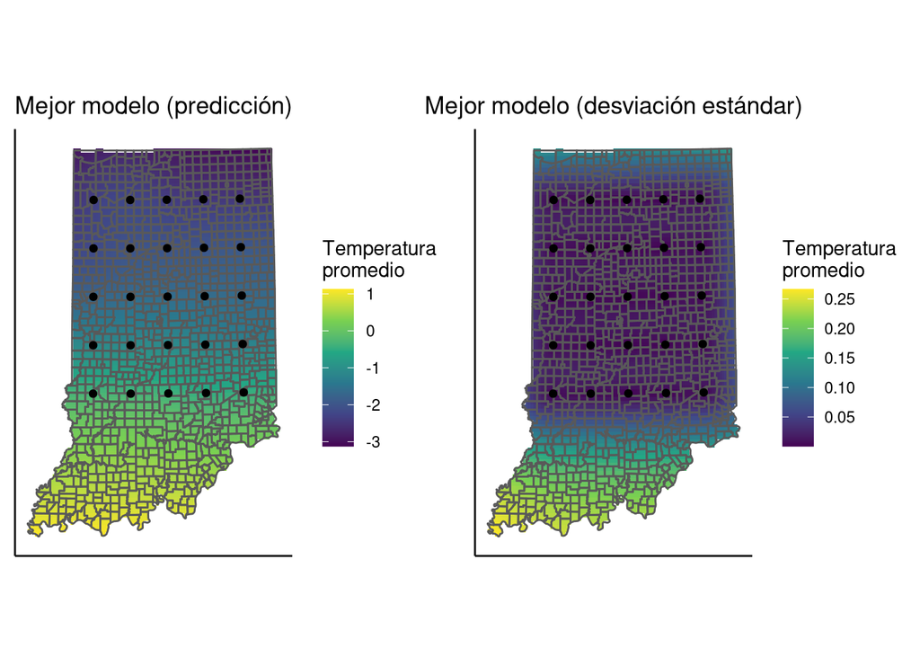

De allí se puede observar que el modelo refleja los principios de autocorrelación espacial, puesto que se espera que lugares geográficos cercanos tengan valores similares y lugares lejanos difieran en el valor de la variable regionalizada en cuestión; lo que es una señal de buen ajuste.

# Conclusiones

- En definitiva los tres primeros meses del año no son ideales para la siembra de maíz, puesto que la temperatura está lejos de ser la requerida y en el mejor de los casos se contará con lugares donde se alcance un máximo de 1 °C.
- Como es de esperarse, el modelo es fiel a la realidad, pues este refleja que los lugares tendrán menor temperatura entre más se encuentren al norte.
- A medida que se aleja geográficamente de los puntos de muestreo, se tiene el comportamiento natural de un aumento en la desviación estándar de las predicciones, sin embargo se alcanza una incertidumbre máxima de 0.25 °C en promedio por lo que se obtuvo no solo un buen ajuste, sino que uno muy fiable en lo que al error de las estimaciones respecta.
- Resulta de gran importancia considerar las tendencias que la respuesta pueda tener con alguna dirección, pues al hacerlo es muy plausible que se pueda obtener mejoría a la hora de analizar resultados en el proceso de modelamiento y predicción.
- En definitiva el modelo gaussiano fue aquel que presentó mejor ajuste para explicar la estructura de covarianza del proceso estocástico en cuestión.